# APIs I: Census

Week 3 · EPPS 6302

Karl Ho

## Week 3

APIs I: Census

## Where we are

Weeks 1 and 2 asked the question. This week is the first **answer**.

- Week 1 — how were these data made?
- Week 2 — how wrong are they, and may I hold them?
- **Week 3 — here is a source that answers both, in writing**

We start with the Census because it is the best-documented data-generating process you will ever touch. Everything after this is measured against it.

## Learning objectives

By the end of today you should be able to:

1. Distinguish between **Decennial Census** and **American Community Survey** applications
2. Execute Census data retrieval using the **API** and **tidycensus**
3. Apply appropriate **geographic levels** to different research questions
4. Create publication-quality **choropleth maps** integrating demographic and spatial data

## Today

1. Web data — two ways in
2. What the Census actually is
3. `tidycensus` in practice
4. Margins of error, and what they do to your claims
5. The reference case: Census against Google Trends

## Web data

Foster ch. 2 — Working with Web Data and APIs

## Four questions before the code

Accumulation of data begins with transaction and interaction between humans. New internet technology scales that up with fast computation, large storage and caching.

1. What is the **purpose** of this web data?
2. What is its **generation process**?
3. What is the **data of data** — the metadata?
4. Why do **social scientists** need to collect it?

Question 2 is the course. It does not stop being the question because the data arrived over HTTP.

## Two technical routes

### Screen scraping

Extract data from the **source code** of a page — an HTML parser, or regular expression matching.

Foster: sites are “designed in ways that make scraping difficult,” and their “structure changes frequently.”

### API

A web service built to be **called**, returning **structured** data.

Reliable, documented, versioned — **when it exists**.

Next week is scraping. This week is the good case.

## What a REST API gives you

- A **documented** set of endpoints and parameters
- **Structured** output — JSON, not markup you must reverse-engineer
- A **contract**: the shape of the response is a promise
- Often a **wrapper package**, so you never write the HTTP call yourself

`tidycensus` is a wrapper. Underneath it is a URL with your key in the query string. Know that, so you can debug it.

## Where the APIs are

- **Social media** — Meta Content Library, YouTube, and what remains of the rest
- **News** organisations
- **Government** — Census, BLS, Eurostat, national statistics offices
- **NGOs** and international organisations

Government APIs are the unglamorous ones, and the only ones built by an institution whose job is to be used.

Weeks 6 and 7 take the first row. Today is the third.

## The manners are part of the method

- **`robots.txt`** — what the site says crawlers may touch
- **Crawl delay** — Foster’s own example sleeps **10 seconds** between requests
- **Rate limits** — how many calls before you are cut off
- **Terms of service** — some platforms permit, some forbid

Week 2’s rule, restated: Terms of Service are not law, law is not ethics, ethics is not method.

## What the Census is

Walker ch. 1 — the US Census and R

## Two products, two purposes

The US Census system is one of the world’s most comprehensive demographic data collection efforts.

### Decennial Census

Constitutional mandate — **apportionment**.

A **complete enumeration**, every ten years.

### American Community Survey

Continuous **sampling** for detailed socioeconomic characteristics.

Replaced the long form.

One counts. The other estimates. Everything downstream follows.

## Decennial Census — key characteristics

- Complete population enumeration — **not sample-based**
- Limited variables: age, sex, race, Hispanic origin, household relationships
- **April 1st reference date** — crucial for temporal comparisons
- Available at **all** geographic levels, down to census blocks

A count has no margin of error. It has coverage error, which is a different and harder problem.

## Decennial, in code

```r
library(tidycensus)
# 2020 Census basic demographics
county_pop_2020 <- get_decennial(     # object built by get_decennial()
  geography = "county",
  variables = "P1_001N",              # total population
  state     = "Texas",
  year      = 2020
)

library(dplyr)
county_pop_2020 %>%                   # view largest counties
  arrange(desc(value)) %>%            # sort by population value
  slice_head(n = 10)
```

Note the column: `value`. Not `estimate`. The function is telling you what kind of number this is.

## ACS — critical differences

- **Sample-based estimates**, with margins of error
- Extensive socioeconomic variables: income, education, employment, housing
- **Rolling reference periods** — past 12 months for income, current status for others
- Two products:
  - **1-year** (populations 65,000+)
  - **5-year** (all geographies)

About 3.5 million households a year — roughly 3% of the population.

## One-year or five-year?

|  | 1-year ACS | 5-year ACS |
| --- | --- | --- |
| **Coverage** | areas of 65,000+ | down to block groups |
| **Period** | a single year | a moving five-year average |
| **Precision** | wider margins | narrower margins |
| **Currency** | most recent | smeared across five years |

A design trade-off, stated openly by the agency that made it. Note how rare that is.

## ACS, in code

```r
# ACS detailed characteristics
tx_demographics <- get_acs(
  geography = "county",
  variables = c(
    median_income  = "B19013_001",
    bach_degree    = "B15003_022",
    med_home_value = "B25077_001"
  ),
  state = "TX",
  year  = 2024
)

# Examine structure
glimpse(tx_demographics)
```

Name your variables at the point of use. `median_income` survives into your plots; `B19013_001` does not explain itself.

## The hierarchy

Nation → region → division → **state** → **county** → **tract** → **block group** → **block**

Each nests cleanly inside the one before it — so you can aggregate up without asking anyone’s permission.

**ZCTAs do not nest.** Zip Code Tabulation Areas cross county and even state lines. If your unit of analysis is a zip code, you have a problem before you have a dataset.

## Choosing a geographic level

| Level | Population size | Best applications |
| --- | --- | --- |
| **Census blocks** | ~100 | environmental studies, traffic analysis |
| **Block groups** | 600–3,000 | community development, targeted services |
| **Census tracts** | ~4,000 | neighborhood analysis, gentrification |
| **Counties** | varies widely | local government planning, service delivery |
| **States / MSAs** | 65,000+ | policy comparison, economic development |

This is week 1’s *unit of analysis* with a population attached to each row.

## The hierarchy, in code

```r
library(tigris); library(stringr)
options(tigris_use_cache = TRUE)

# Counties contain census tracts
dallas_county <- counties(state = "TX") %>%
  filter(str_detect(NAME, "Dallas"))

dallas_tracts <- tracts(state = "TX", county = "Dallas")

ggplot() +
  geom_sf(data = dallas_county, fill = "lightblue", alpha = 0.5) +
  geom_sf(data = dallas_tracts, fill = NA,
          color = "darkred", size = 0.3) +
  theme_void() +
  labs(title = "Geographic Hierarchy: Dallas County and Census Tracts")
```

## One county, 500-odd tracts

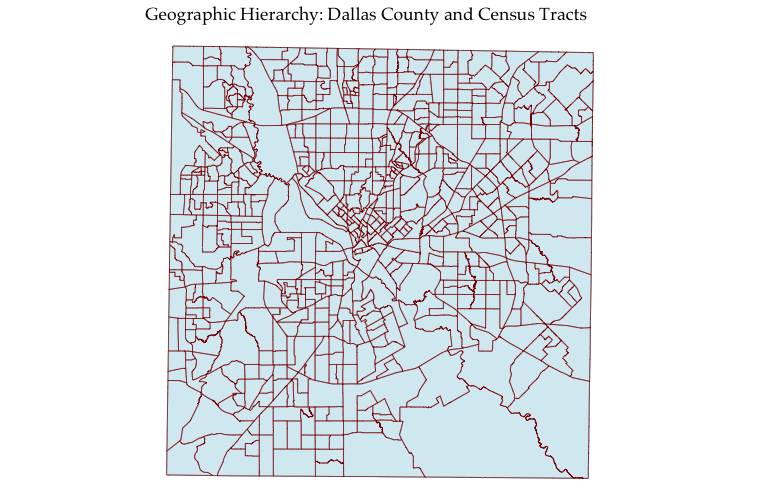

Same county. Two different units of analysis, and two different papers.

## The API, since 2012

Before: download a fixed table someone else decided to publish.

After: **request the table you want** — geography, variables, vintage — and get it back as data.

- Hundreds of datasets behind one documented endpoint
- Free key, no cost, no negotiation
- Most people reach it through a library: `tidycensus`

https://www.census.gov/data/developers/guidance/api-user-guide.html

## tidycensus

Walker ch. 2

## Two functions carry the chapter

- **`get_decennial()`** — decennial Census: 2000, 2010, 2020
- **`get_acs()`** — ACS, back to 2005

```r
library(tidycensus)
census_api_key("YOUR_KEY", install = TRUE)   # once, in the console
```

`install = TRUE` writes the key to `.Renviron` once. It never belongs in a `.qmd` that is going onto your public website.

## What comes back

`get_acs()` returns one row per area per variable:

| GEOID | NAME | variable | estimate | moe |
| --- | --- | --- | --- | --- |
| 48113 | Dallas County, Texas | B19013_001 | 70,000 | 900 |

- `get_decennial()` gives `value` — because it is a **count**
- `get_acs()` gives `estimate` **and** `moe` — because it is a **sample**

## Tidy or wide

### Default — tidy

One row per area per variable.

Good for `ggplot`, `group_by`, faceting.

### `output = "wide"`

One row per area. Estimates and margins become paired columns with **E** and **M** suffixes.

Good for joining, mapping, computing rates.

Use `output = "wide"` rather than pivoting an `sf` object by hand — pivoting tends to drop the spatial class.

## Finding the variable you want

```r
vars <- load_variables(2024, "acs5")
```

- Thousands of variables; browse them in RStudio’s viewer
- Table IDs carry meaning: `B19013_001` is table **B19013**, line **001**
- Name them at the point of use: `c(income = "B19013_001")`

`load_variables()` no longer takes `cache` — current tidycensus reports it *“deprecated and ignored.”* Variable metadata now comes straight from the API.

## A live pull

```r
library(tidycensus); library(ggplot2)
options(tigris_use_cache = TRUE)

tx <- get_acs(geography = "county",
              variables = c(income = "B19013_001"),
              state     = "TX",
              year      = 2024,
              survey    = "acs5",
              geometry  = TRUE,
              output    = "wide")

ggplot(tx) +
  geom_sf(aes(fill = incomeE), color = NA) +
  scale_fill_viridis_c(name = "Median HH income") +
  theme_void()
```

The 2020–2024 ACS 5-year was released **29 January 2026** — that is the current vintage.

## Margins of error

The most critical concept for ACS interpretation

## Every ACS number is an interval

Margins of error quantify **sampling uncertainty**, published at the **90%** confidence level.

$$\text{estimate} \pm \text{moe}$$

- A county at 70,000 ± 900 is a different claim from 70,000 ± 12,000
- Small areas and small subgroups have large margins — that is the sample design showing through, not an error

The 1-year ACS is more current **and** less precise. You cannot have both.

## What overlap does to a ranking

You publish a table: county A first, county B second.

- A: 70,000 ± 8,000 → [62,000, 78,000]
- B: 68,000 ± 9,000 → [59,000, 77,000]

The intervals overlap almost entirely. **You have not shown that A is richer than B.** You have shown you cannot tell.

## Test it, don’t eyeball it

```r
# Proper significance testing between two estimates
compare_significance <- function(est1, moe1, est2, moe2) {
  se1 <- moe1 / 1.645
  se2 <- moe2 / 1.645

  test_statistic <- abs(est1 - est2) / sqrt(se1^2 + se2^2)

  return(list(
    test_stat      = test_statistic,
    significant_90 = test_statistic > 1.645,
    significant_95 = test_statistic > 1.960
  ))
}

m <- metro_income
result <- compare_significance(m$estimate[1], m$moe[1],
                               m$estimate[2], m$moe[2])
print(result)
```

**1.645** converts a 90% MOE back to a standard error. Everything else is a two-sample test.

## How reliable is this estimate?

```r
msa <- "metropolitan statistical area/micropolitan statistical area"

metro_income <- get_acs(
  geography = msa,
  variables = "B19013_001",
  year      = 2024,
  survey    = "acs1"          # 1-year estimates for larger areas
) %>%
  mutate(
    cv = moe / 1.645 / estimate,   # SE, then CV
    reliability = case_when(
      cv <= 0.15 ~ "High",
      cv <= 0.30 ~ "Moderate",
      cv >  0.30 ~ "Low"
    )
  )
```

A CV rescales the margin by the estimate — reliability becomes comparable across places.

## Carry the uncertainty through

If you derive a quantity, derive its margin too:

- `moe_sum()` — adding estimates
- `moe_prop()` — a proportion, e.g. a poverty **rate**
- `moe_ratio()` · `moe_product()`

```r
mutate(pov_rate = povE / povdenE,
       pov_moe  = moe_prop(povE, povdenE, povM, povdenM))
```

Dropping the MOE at the first `mutate()` is the most common way a good ACS analysis goes quietly wrong.

## The reference case

Census against last week’s data

## Two data-generating processes

|  | **ACS** | **Google Trends** |
| --- | --- | --- |
| Sample design | published | undisclosed |
| Units | people, households | a rescaled index |
| Uncertainty | shipped with the data | none given |
| Re-run the query | same answer | different answer |
| Documentation | thousands of pages | a help article |
| Who made it, and why | a public agency, to be used | a company, for itself |

Both are “found” data. Only one hands you its data-generating process.

## So what does that buy you?

- You can state your unit of analysis and defend it
- You can put an interval on every number you publish
- Someone else can reproduce your pull exactly
- Your datasheet almost writes itself

Next week the supports come away: **static scraping**, where there is no key, no contract, no margin of error, and the page may change tomorrow.

## Before next week

- **Assignment 3** — ACS via `tidycensus`, one map, one table, MOEs taken seriously
- Foster ch. 2, scraping §2.2
- R4DS (2e) ch. 24, *Web scraping*
- Two R scraping packages, compared
- Two `robots.txt` files, read and analysed

## Readings

- Foster et al. ch. 2 — https://textbook.coleridgeinitiative.org/chap-web.html
- Walker ch. 1 — https://walker-data.com/census-r/the-united-states-census-and-the-r-programming-language.html
- Walker ch. 2 — https://walker-data.com/census-r/an-introduction-to-tidycensus.html
- Census API user guide — https://www.census.gov/data/developers/guidance/api-user-guide.html
- *Rec.:* Schlegel ch. 3 — Indices

## Questions

**karlho@utdallas.edu** · GR 3.203

Office hours: Wednesday & Thursday, 10–12 noon